# Презентация Лабороторной работы №6

Операционные системы

Дьяконова С. А.

Российский университет дружбы народов, Москва, Россия

18 марта 2023

# Информация

## Докладчик

- Дьяконова Софья Александровна
- студент
- студент кафедры компьютерных и информационных наук
- Российский университет дружбы народов
- 1132220829@pfur.ru
- https://github.com/sadjyakonova/study_2022-2023_os-intro

## Актуальность

- Способность управлять процессами (и заданиями), по проверке использования диска и обслуживанию файловых систем.

## Объект и предмет исследования

- Функционал Linux для работы с файловыми системами через терминал.

## Цели и задачи

Цель работы – ознакомление с инструментами поиска файлов и фильтрации текстовых данных. Задачи – Приобретение практических навыков: по управлению процессами (и заданиями), по проверке использования диска и обслуживанию файловых систем.

## Задание

1. Осуществите вход в систему, используя соответствующее имя пользователя.
2. Запишите в файл file.txt названия файлов, содержащихся в каталоге /etc. Допи- шите в этот же файл названия файлов, содержащихся в вашем домашнем каталоге.
3. Выведите имена всех файлов из file.txt, имеющих расширение .conf, после чего запишите их в новый текстовой файл conf.txt. Кулябов Д. С. и др. Операционные системы 59
4. Определите, какие файлы в вашем домашнем каталоге имеют имена, начинавшиеся с символа c? Предложите несколько вариантов, как это сделать.
5. Выведите на экран (по странично) имена файлов из каталога /etc, начинающиеся с символа h.
6. Запустите в фоновом режиме процесс, который будет записывать в файл ~/logfile файлы, имена которых начинаются с log.
7. Удалите файл ~/logfile.
8. Запустите из консоли в фоновом режиме редактор gedit.
9. Определите идентификатор процесса gedit, используя команду ps, конвейер и фильтр grep. Как ещё можно определить идентификатор процесса?
10. Прочтите справку (man) команды kill, после чего используйте её для завершения процесса gedit.
11. Выполните команды df и du, предварительно получив более подробную информацию об этих командах, с помощью команды man.
12. Воспользовавшись справкой команды find, выведите имена всех директорий, имеющихся в вашем домашнем каталоге.

## Теоретическое введение

В системе по умолчанию открыто три специальных потока: – stdin — стандартный поток ввода (по умолчанию: клавиатура), файловый дескриптор 0; – stdout — стандартный поток вывода (по умолчанию: консоль), файловый дескриптор 1; – stderr — стандартный поток вывод сообщений об ошибках (по умолчанию: консоль), файловый дескриптор 2. Большинство используемых в консоли команд и программ записывают резуль- таты своей работы в стандартный поток вывода stdout. Например, команда ls выводит в стандартный поток вывода (консоль) список файлов в текущей ди- ректории. Потоки вывода и ввода можно перенаправлять на другие файлы или устройства. Проще всего это делается с помощью символов >, », <, «. Конвейер (pipe) служит для объединения простых команд или утилит в цепочки, в которых результат работы предыдущей команды передаётся последующей. Синтаксис следующий: команда 1 | команда 2 # означает, что вывод команды 1 передастся на ввод команде 2 Конвейеры можно группировать в цепочки и выводить с помощью перена- правления в файл, например: ls -la |sort > sortilg_list вывод команды ls -la передаётся команде сортировки sort\verb, которая пишет результат в файл sorting_list\verb. 7 Чаще всего скрипты на Bash используются в качестве автоматизации каких- то рутинных операций в консоли, отсюда иногда возникает необходимость в обработке stdout одной команды и передача на stdin другой команде, при этом результат выполнения команды должен обработан. Команда find используется для поиска и отображения на экран имён файлов, соответствующих заданной строке символов. Найти в текстовом файле указанную строку символов позволяет команда grep. Формат команды: grep Кроме того, команда grep способна обрабатывать стандартный вывод других команд (любой текст). Для этого следует использовать конвейер, связав вывод команды с вводом grep. Команда df показывает размер каждого смонтированного раздела диска. Фор- мат команды: df <-опции> Любую выполняющуюся в консоли команду или внешнюю программу можно запустить в фоновом режиме. Для этого следует в конце имени команды указать знак амперсанда &. Любой команде, выполняемой в системе, присваивается идентификатор про- цесса (process ID). Получить информацию о процессе и управлять им, пользуясь идентификатором процесса, можно из любого окна командного интерпретатора. Команда ps используется для получения информации о процессах. Формат команды: ps <-опции> Для получения информации о процессах, управляемых вами и запущенных (работающих или остановленных) на вашем терминале, используйте опцию aux. Пример: ps aux.

## Выполнение лабораторной работы

## Осуществление входа в систему, запись в файл file.txt названия файлов, содержащихся в каталоге /etc и в домашнем каталоге.

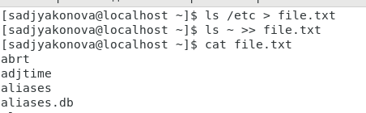

file.txt

## Вывод имен всех файлов из file.txt, имеющих расширение .conf.

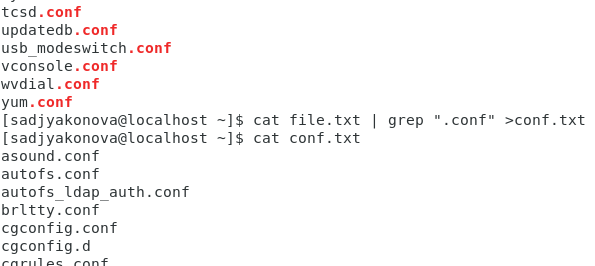

conf.txt

## Файлы в домашнего каталога имеющие имена, начинаюшиеся с символа c

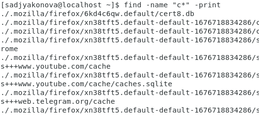

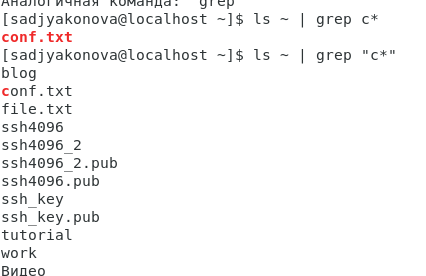

## Вывод на экран (по странично) имен файлов из каталога /etc, начинающиеся с символа h.

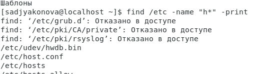

## Запуск в фоновом режиме процесса, который будет записывать в файл ~/logfile файлы, имена которых начинаются с log.

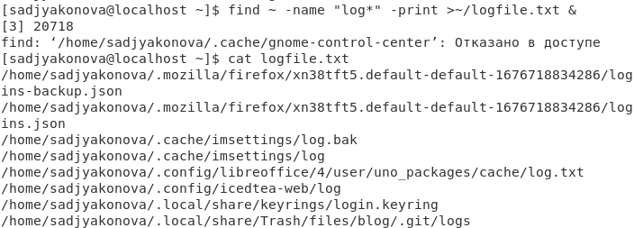

файлы на log

## Удаление файл ~/logfile.

rm logfile

## Команда kill, использование её для завершения процесса gedit.

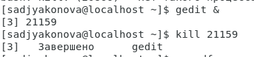

kill

## Выполнение команды df и du.

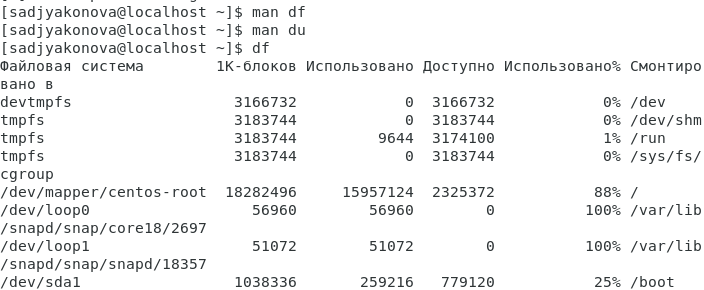

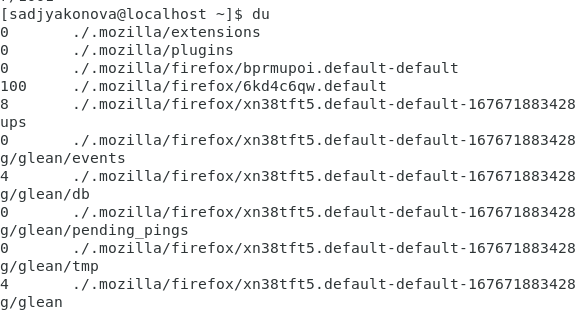

## Вывод имен всех директорий, имеющихся в моем домашнем каталоге.

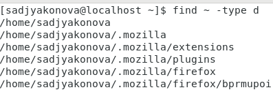

Все директории

## Выводы

В ходе выполнения лабораторной работы я ознакомилась с инструментами поиска файлов и фильтрации текстовых данных. Приобрела практические навыки: по управлению процессами (и заданиями), по проверке использования диска и обслуживанию файловых систем.